# DS3 projects

Matthew Munoz and Fabio Pecora

2024-06-24

# **Anti-Immigrant Rhetoric and ICE Reporting Interest: Evidence from a Large-Scale Study of Web Search Data Replication and Extension**

**1) Trends and functions**  
Functions for table and figure replication  
Google trend terms  
Positive Google trend terms

**2) Original Data**  
Original data plot  
Original data ordinary least square regression

**3) Gathered Data**  
Gathered data plot  
Gathered data ordinary least square regression

**4) Topic Model**  
Topic Model  
Media coverage and reporting search trends

**5) Extension**  
Extension  
Proportion of fear vs positive search terms  
Plotting proportion of fear vs positive search terms by presidency  
Displaying fear and positive searches by state between 2004 and 2020

## Loading libraries

```r
library(tidyverse)
library(zoo)
library(stm)
library(maps)
library(stringr)
```

## Functions for table and figure replication

#### Date manipulation

The current Google trends only includes the year-month. This functions adds a day component to make it year-month-date while also converting the string to a date to allow later partitions to be more accurate.

```r
add_date <- function(df) {
  # formats the data to have the date as a date that includes day
  df <- df |>
    mutate(ymd=as.Date(paste(ym, "-20", sep=""))) |>
    select(-ym)
  }
```

#### Inserting presidential terms

This function further simplifies the partitioning by adding a column that distinguishes which president is serving on that date.

```r
add_pres <- function(df) {
  # variables to partition the presidential terms
  bush_end <- as.Date("2009-01-20")
  trump_start <- as.Date("2017-01-20")

  # add the corresponding term to that month
  df$president <-
    ifelse(df$ymd >= bush_end & df$ymd < trump_start, "Obama",
           ifelse(df$ymd < bush_end, "Bush", "Trump"))

  return(df)
}
```

#### Categorizing presidential terms

Creates three new columns, one for each president, that holds dummy variables (i.e. 0 or 1) to allow the linear model to run effectively.

```r
zero_or_one <- function(df) {
  # adds three columns, one for each president and subsequently add a 1 when it is their presidency
  df$bush <-
    ifelse(df$president == "Bush", 1, 0)
  df$obama <-
    ifelse(df$president == "Obama", 1, 0)
  df$trump <-
    ifelse(df$president == "Trump", 1, 0)

  return(df)
}
```

#### Plot 4 recreation

Recreation of the point plot with linear smoothing for easier understanding.The plot separates the points and lines by presidency.

```r
plot_4 <- function(df, start, end, title) {
  # recreated figure 4 from the paper
  df |>
    ggplot(aes(x = ymd, y = trends, color = president)) +
    geom_point(shape = 1) +
    geom_smooth(method = "lm", se = FALSE) +
    ylim(start, end) +
    xlab("Year") +
    ylab("Google Trends") +
    ggtitle(title)
}
```

### Google trend terms

**Report**: report immigrant+report immigration+report illegals+report illegal alien+report to ice  
**Crime**: immigrant crime+immigrant criminal+immigrant murder+immigrant kill  
**Welfare**: immigrant welfare+immigrant cost+immigrant benefits

### Loading original data

The original data used in the paper is loaded and manipulated to include the correct date, presidential terms, and dummy variables.

```r
# loading original data
report_og <- read.csv("google-trends data/original research data/google_trends_report.csv")
crime_og <- read.csv("google-trends data/original research data/google_trends_crime.csv")
welfare_og <- read.csv("google-trends data/original research data/google_trends_welfare.csv")

# inserting proper column names
colnames(report_og) <- c("y", "m" ,"trends")
colnames(crime_og) <- c("y", "m","trends")
colnames(welfare_og) <- c("y", "m","trends")

# converting to reproducible format
report_og$ym <- with(report_og, sprintf("%d-%02d", y, m))
crime_og$ym <- with(crime_og, sprintf("%d-%02d", y, m))
welfare_og$ym <- with(welfare_og, sprintf("%d-%02d", y, m))

# keep only necessary columns
report_og <- report_og |> select(ym, trends)
crime_og <- crime_og |> select(ym, trends)
welfare_og <- welfare_og |> select(ym, trends)

# uses the add_date function
report_og <- add_date(report_og)
crime_og <- add_date(crime_og)
welfare_og <- add_date(welfare_og)

# uses the add_pres function
report_og <- add_pres(report_og)
crime_og <- add_pres(crime_og)
welfare_og <- add_pres(welfare_og)

# uses the zero_or_one function, which is the final desired form
report_og <- zero_or_one(report_og)
crime_og <- zero_or_one(crime_og)
welfare_og <- zero_or_one(welfare_og)
```

## Original plot

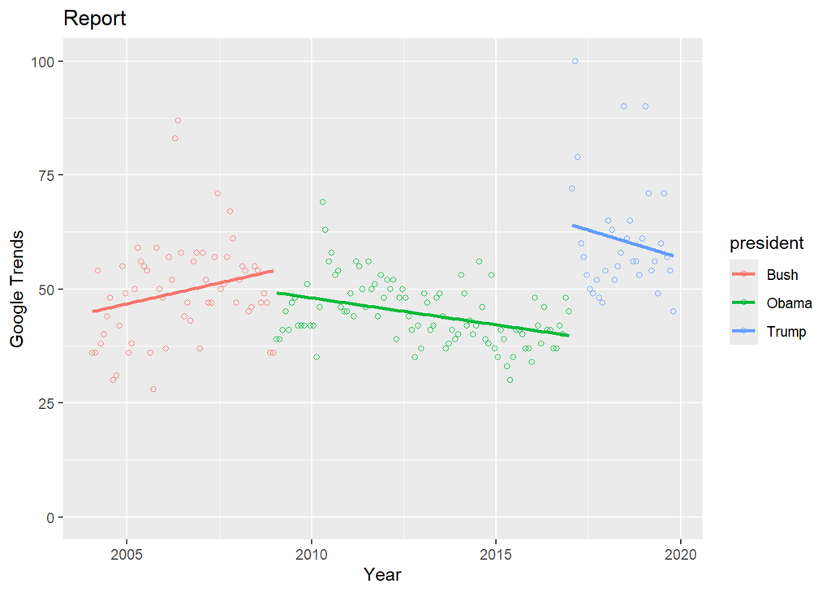

```r
plot_4(report_og, 0, 100, "Report")
```

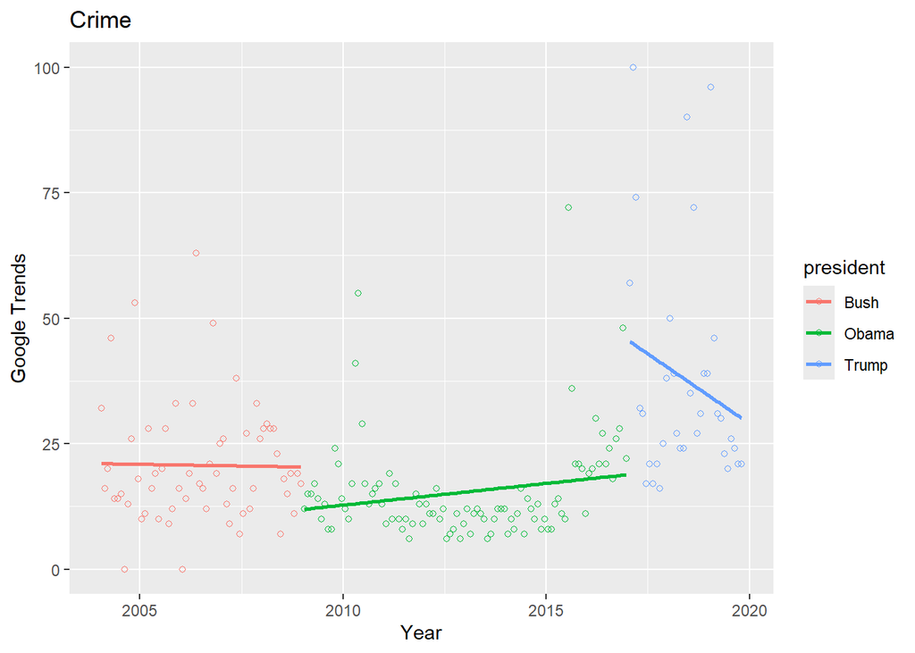

```r
plot_4(crime_og, 0, 100, "Crime")
```

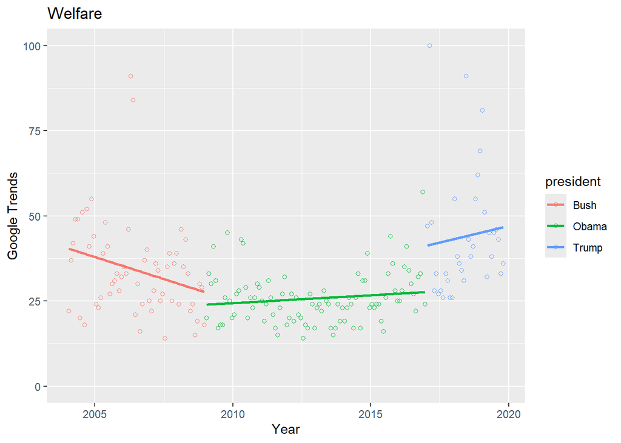

```r
plot_4(welfare_og, 0, 100, "Welfare")
```

**Figure 1.** *Original Immigration searches by administration*  
For all three sets of anti-immigrant terms, searches increased on Google after Trump’s inauguration speech. There was also a spike in all three sets of terms in the months immediately after the inauguration.

## Original data ordinary least square regression

```r
fit.report_og <- lm(trends~ymd+bush+trump+obama, data=report_og |> filter(trends > 0))
fit.crime_og <- lm(trends~ymd+bush+trump+obama, data=crime_og |> filter(trends > 0))
fit.welfare_og <- lm(trends~ymd+bush+trump+obama, data=welfare_og |> filter(trends > 0))
summary(fit.report_og)
```

```
##
## Call:
## lm(formula = trends ~ ymd + bush + trump + obama, data = filter(report_og,
##     trends > 0))
##
## Residuals:
##     Min      1Q  Median      3Q     Max
## -22.050  -5.662  -1.293   4.796  38.482
##
## Coefficients: (1 not defined because of singularities)
##              Estimate Std. Error t value Pr(>|t|)
## (Intercept) 72.607670  16.108626   4.507 1.16e-05 ***
## ymd         -0.001789   0.001024  -1.748   0.0821 .
## bush         0.785389   2.898559   0.271   0.7867
## trump       19.716343   2.787848   7.072 2.99e-11 ***
## obama              NA         NA      NA       NA
## ---
## Signif. codes:  0 '***' 0.001 '**' 0.01 '*' 0.05 '.' 0.1 ' ' 1
##
## Residual standard error: 9.601 on 186 degrees of freedom
## Multiple R-squared:  0.2863, Adjusted R-squared:  0.2748
## F-statistic: 24.87 on 3 and 186 DF,  p-value: 1.411e-13
```

```r
summary(fit.crime_og)
```

```
##
## Call:
## lm(formula = trends ~ ymd + bush + trump + obama, data = filter(crime_og,
##     trends > 0))
##
## Residuals:
##     Min      1Q  Median      3Q     Max
## -21.526  -7.106  -3.603   3.434  62.727
##
## Coefficients: (1 not defined because of singularities)
##              Estimate Std. Error t value Pr(>|t|)
## (Intercept) -1.024897  23.183622  -0.044   0.9648
## ymd          0.001045   0.001473   0.710   0.4789
## bush         8.501543   4.163079   2.042   0.0426 *
## trump       20.300850   4.006843   5.067 9.81e-07 ***
## obama              NA         NA      NA       NA
## ---
## Signif. codes:  0 '***' 0.001 '**' 0.01 '*' 0.05 '.' 0.1 ' ' 1
##
## Residual standard error: 13.78 on 184 degrees of freedom
## Multiple R-squared:  0.266,  Adjusted R-squared:  0.254
## F-statistic: 22.23 on 3 and 184 DF,  p-value: 2.502e-12
```

```r
summary(fit.welfare_og)
```

```
##
## Call:
## lm(formula = trends ~ ymd + bush + trump + obama, data = filter(welfare_og,
##     trends > 0))
##
## Residuals:
##     Min      1Q  Median      3Q     Max
## -19.966  -7.986  -1.646   4.774  56.953
##
## Coefficients: (1 not defined because of singularities)
##              Estimate Std. Error t value Pr(>|t|)
## (Intercept) 28.587926  20.734642   1.379   0.1696
## ymd         -0.000178   0.001318  -0.135   0.8927
## bush         7.819065   3.730956   2.096   0.0375 *
## trump       18.560493   3.588452   5.172 5.95e-07 ***
## obama              NA         NA      NA       NA
## ---
## Signif. codes:  0 '***' 0.001 '**' 0.01 '*' 0.05 '.' 0.1 ' ' 1
##
## Residual standard error: 12.36 on 186 degrees of freedom
## Multiple R-squared:  0.237,  Adjusted R-squared:  0.2247
## F-statistic: 19.26 on 3 and 186 DF,  p-value: 6.428e-11
```

**Table 1.** *Original immigration searches by presidential administration*  
After accounting for the linear time trend, there was still a clear increase in immigrant reporting searches after Trump’s inauguration. The regression is OLS on monthly search interest.

## Loading gathered Google trends data

The gathered is loaded and manipulated to include the correct date, presidential terms, and dummy variables

```r
# loading gathered data
report <- read.csv("google-trends data/replicate data/report.csv")
crime <- read.csv("google-trends data/replicate data/crime.csv")
welfare <- read.csv("google-trends data/replicate data/welfare.csv")

# inserting proper column names
colnames(report) <- c("ym" ,"trends")
colnames(crime) <- c("ym","trends")
colnames(welfare) <- c("ym","trends")

# uses the add_date function
report <- add_date(report)
crime <- add_date(crime)
welfare <- add_date(welfare)

# uses the add_pres function
report <- add_pres(report)
crime <- add_pres(crime)
welfare <- add_pres(welfare)

# uses the zero_or_one function, which is the final desired form
report <- zero_or_one(report)
crime <- zero_or_one(crime)
welfare <- zero_or_one(welfare)
```